# BasicGraphAssignment

```python
##import matplotlib and pandas
import matplotlib.pyplot as plt
import pandas as pd

##read files
dfOpiod = pd.read_csv('C:\\Users\\Cora\\Documents\\haleigh\\BUAD 5112\\CTBA\\M2\\OpidsVA.csv')
dfPres = pd.read_csv('C:\\Users\\Cora\\Documents\\haleigh\\BUAD 5112\\CTBA\\M2\\presidents.csv')
dfTot = pd.read_csv('C:\\Users\\Cora\\Documents\\haleigh\\BUAD 5112\\CTBA\\M2\\TOTALNSA.csv')
```

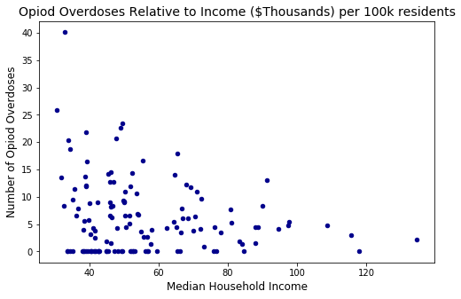

```python
##change values of median income to 1,000's
dfOpiod['MedianHouseholdIncome'] = (dfOpiod['MedianHouseholdIncome'] / 1000)

##determine Income/Opiod relationship and defineplot type, x/y axis values, size, and color of dots
##I chose a scatterplot to best determine the relationship between income and opiod overdoses. It easily shows how one relates to the other.
ax = dfOpiod.plot(kind='scatter', x='MedianHouseholdIncome', y='FPOO-Rate', figsize=(8,5), color='darkblue')

##set labels for x & y axes and title
ax.set_xlabel('Median Household Income', fontsize=12)
ax.set_ylabel('Number of Opiod Overdoses', fontsize=12)
ax.set_title('Opiod Overdoses Relative to Income ($Thousands) per 100k residents', fontsize=14)
plt.show()
```

1. Do opioid overdoes tend to be associated with less affluent areas—that is, areas where families have lower incomes?
   - According to the data and how it presents itself within the scatterplot, it shows opiod overdoses are associated with less affluent areas. The trend of the plotted data points show the bulk of the of overdoses happen when income is between 30 and 80 thousand with fewer overdoses when income is between 80 and 120 thousand.

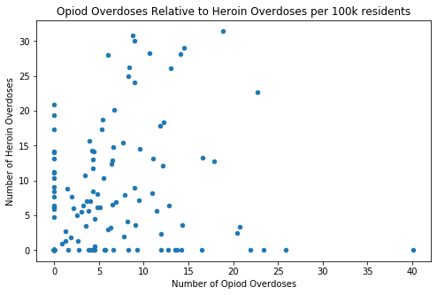

```python
##determine Opiod/Heroin relationship and defineplot type, x/y axis values, size, title, and color of dots
##I chose to use a scatterplot for this question as well because it shows the relationship between Opiod/Heroin overdoses clearly
bx = dfOpiod.plot(kind='scatter', x='FPOO-Rate', y='FFHO-Rate', figsize=(8,5))

##set labels and title for new plot
bx.set_xlabel('Number of Opiod Overdoses')
bx.set_ylabel('Number of Heroin Overdoses')
bx.set_title('Opiod Overdoses Relative to Heroin Overdoses per 100k residents')
plt.show()
```

1. Some people who start with opioid addictions are reported to transition to heroin use. What is the relationship in Virginia counties between opioid overdoses and heroin overdoses?
   - Although the data shows a few high number of overdoses on heroin when the opiod overdoses are high as well, the majority opiod and heroin overdoses that happen occur independently of each other. There is a relationship between the two, but not a strong one.

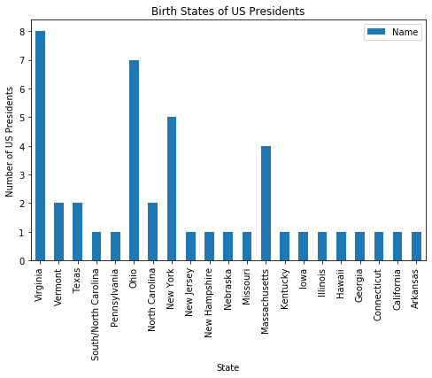

```python
##determine Income/Opiod relationship and defineplot type, x/y axis values, size, title, and color of dots
##I chose to use a bar graph for this question because it easily shows the number of presidents born in each state and highlights the most vs least
cx = dfPres.groupby(['State']).count().sort_values(['State'], ascending=False).plot(kind='bar', y=['Name'], figsize=(8,5))

##set labels and title for new plot
cx.set_xlabel('State')
cx.set_ylabel('Number of US Presidents')
cx.set_title('Birth States of US Presidents')
plt.show()
```

1. Which states are associated with the greatest number of United States presidents in terms of the presidents’ birthplaces?
   - As shown in the graph, Virginia is the state with the greatest number of US presidents having been born there. Ohio 2nd and New York 3rd.

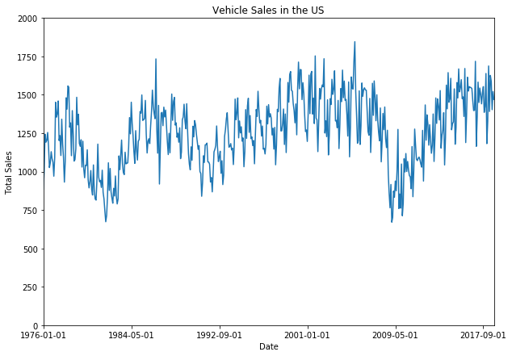

```python
##determine Income/Opiod relationship and defineplot type, x/y axis values, size, title, and color of dots
##I chose a line graph for this question because it includes time, and line graphs are easily read as a line over time.
dx = dfTot.groupby('DATE')['TOTALNSA'].mean().plot(kind='line', x='DATE', y='TOTALNSA', figsize=(10,7))

##set labels and title for new plot
dx.set_xlabel('Date')
dx.set_ylabel('Total Sales')
dx.set_ylim([0,2000])
dx.set_title('Vehicle Sales in the US')
plt.show()
```

1. How have vehicle sales in the United States varied over time?
   - The data shows vehicle sales in the US although having varying the entire span between 1976 to 2018, keeps a consistent trend throughout each year. Beginning of each year shows sales down, rising as spring comes, dropping mid summer, coming back up early fall and back down in winter. Two major dips are seen near 1982 timeframe and 2008 timeframe while two major spikes are shown near 1987 and 2005.